# Lecture 1 – NLP: Basic Concepts and Approaches

SIMM59: Document Research in the Social Sciences 2026

nils.holmberg@iko.lu.se

## Presentation

- Nils Holmberg
- Computational  
  content analysis
- Cognitive  
  communication effects

[video not shown]

## Course literature

[figure not shown]

Ghosh and Gunning (2019)

[figure not shown]

Tight (2019)

[figure not shown]

Vasiliev (2020)

## Lecture overview

- Data analysis framework
- Data types
- Data frames
- Data structures
- `Selecting data`
- Importing data
- Subsetting data
- Research questions
- `Transforming data`
- Adding data
- Grouping data
- Reshaping data
- Exporting data frames
- Visualizing data

## Document Analysis in Context

- Document analysis studies meaning in texts.
- Sources include reports, posts, transcripts, and articles.
- Coding can be manual, rule-based, or model-assisted.
- Research questions guide categories and evidence.
- NLP scales analysis across larger corpora.

## Core NLP Tasks for Document Research

- Sentiment analysis estimates evaluative tone.
- Topic modelling groups recurring semantic themes.
- LLM coding can draft labels and summaries.
- Vector databases support semantic search workflows.
- Knowledge graphs connect entities and relations.

## From Questions to Analytical Pipelines

- Start with a narrow substantive question.
- Match methods to unit of analysis.
- Combine qualitative reading with computation.
- Validate outputs against sampled documents.
- Keep interpretation tied to context.

## Multimodal Content Analysis

- Communication often mixes text, image, and sound.
- Multimodal analysis compares channels jointly.
- Metadata helps align content across formats.
- Different modalities require different features.
- Interpretation should integrate all signals.

## Computer Vision Tasks for Social Data

- Facial emotion models estimate visible affect.
- Demographic models infer coarse attributes.
- Object detection locates people and items.
- Pose estimation tracks body configuration.
- Outputs are probabilistic, not factual.

## Risks and Uses of Vision Analysis

- Bias varies across groups and settings.
- Context loss can distort visual meaning.
- Ethical review matters for sensitive data.
- Human oversight remains essential.
- Best use combines vision with substantive theory.

## Chapter 1: What is NLP?

- Enables machines to understand and generate language
- Intersection of AI, linguistics, and statistics
- Shifted from rule-based systems to ML in the 1980s
- Text analytics asks *what*; NLP asks *why* and *how*
- Applications: translation, search, summarization

*Ch. 1, “Introduction” and “History of NLP”*

## Text Analytics vs NLP

- Text analytics extracts counts and surface patterns
- NLP comprehends meaning and generates language
- NLP includes speech recognition as input
- Both require preprocessing as a first step
- Pipeline structure depends on the end task

*Ch. 1, “Text Analytics and NLP”*

|  |  | Text Analytics | NLP |
| --- | --- | --- | --- |
| 0 | Goal | Count & pattern | Understand meaning |
| 1 | Output | Metrics | Language |
| 2 | Example task | Frequency table | Named entity finder |

## The NLP Pipeline

- Ordered sequence of interdependent steps
- Each step builds on the output of the previous
- Pipeline composition driven by research task
- NLTK and spaCy implement the full pipeline
- Preprocessing decisions cascade through all steps

*Ch. 1, “Various Steps in NLP”*

|  | Step | Input → Output |
| --- | --- | --- |
| 0 | Sentence split | document → sentences |
| 1 | Tokenize | sentence → tokens |
| 2 | Remove stops | tokens → fewer tokens |
| 3 | Normalize | tokens → lowercase |
| 4 | Lemmatize | tokens → base forms |

## Tokenization

- Split text into atomic units called *tokens*
- Word boundaries are not always obvious
- Contractions: *don’t* → *do* + *n’t*
- Punctuation may be attached to words
- spaCy applies language-specific splitting rules

*Ch. 1, “Tokenization”*

```python
doc = nlp("Equinor's 2024 net-zero target.")
pd.DataFrame(
    [(i, t.text, t.is_punct) for i, t in enumerate(doc)],
    columns=["idx", "token", "is_punct"]
)
```

|  | idx | token | is_punct |
| --- | --- | --- | --- |
| 0 | 0 | Equinor | False |
| 1 | 1 | 's | False |
| 2 | 2 | 2024 | False |
| 3 | 3 | net | False |
| 4 | 4 | - | True |
| 5 | 5 | zero | False |
| 6 | 6 | target | False |
| 7 | 7 | . | True |

## Part-of-Speech Tagging

- Assigns grammatical category to each token
- Context-dependent: *bank* (noun vs. verb)
- Uses Penn Treebank tagset (45 fine-grained tags)
- Critical for parsing, NER, and lemmatization
- spaCy uses a neural tagger trained on OntoNotes

*Ch. 1, “PoS Tagging”*

```python
doc = nlp("Equinor reduces carbon emissions annually.")
pd.DataFrame(
    [(t.text, t.pos_, t.tag_) for t in doc],
    columns=["token", "POS", "tag"]
)
```

|  | token | POS | tag |
| --- | --- | --- | --- |
| 0 | Equinor | NOUN | NN |
| 1 | reduces | VERB | VBZ |
| 2 | carbon | NOUN | NN |
| 3 | emissions | NOUN | NNS |
| 4 | annually | ADV | RB |
| 5 | . | PUNCT | . |

## Stop Word Removal

- Function words carry little content information
- *the*, *is*, *of*, *in* appear in every document
- spaCy English: 326 built-in stop words
- Removal foregrounds content-bearing terms
- **Research decision:** not always appropriate

*Ch. 1, “Stop Word Removal”*

```python
doc = nlp("The company is reducing its carbon emissions.")
pd.DataFrame(
    [(t.text, t.is_stop, t.lemma_) for t in doc],
    columns=["token", "stop?", "lemma"]
)
```

|  | token | stop? | lemma |
| --- | --- | --- | --- |
| 0 | The | True | the |
| 1 | company | False | company |
| 2 | is | True | be |
| 3 | reducing | False | reduce |
| 4 | its | True | its |
| 5 | carbon | False | carbon |
| 6 | emissions | False | emission |
| 7 | . | False | . |

## Text Normalization

- Lowercasing: *Companies* = *companies*
- Remove punctuation and special characters
- Apply minimum token length filter
- Handle encoding variation (UTF-8)
- All choices must match the research question

*Ch. 1, “Text Normalization”*

```python
raw = "Equinor's Emissions REPORT, 2024!"
pd.DataFrame({
    "step":   ["raw", "lowercase", "alpha only", "len ≥ 3"],
    "result": [
        raw,
        raw.lower(),
        re.sub(r"[^a-z\s]", "", raw.lower()).strip(),
        " ".join(w for w in re.sub(r"[^a-z\s]","",
                 raw.lower()).split() if len(w) >= 3)]
})
```

|  | step | result |
| --- | --- | --- |
| 0 | raw | Equinor's Emissions REPORT, 2024! |
| 1 | lowercase | equinor's emissions report, 2024! |
| 2 | alpha only | equinors emissions report |
| 3 | len ≥ 3 | equinors emissions report |

## Stemming vs Lemmatization

- Both reduce inflected tokens to a base form
- **Stemming:** heuristic suffix stripping, fast
- **Lemmatization:** dictionary + morphology, accurate
- Stemming may produce non-words (*acceler*)
- Lemmatization preferred for interpretable output

*Ch. 1, “Stemming” and “Lemmatization”*

```python
words = ["reducing", "emissions", "strategies",
         "accelerating", "reported"]
pd.DataFrame({
    "word":  words,
    "lemma": [nlp(w)[0].lemma_ for w in words],
    "stem":  [porter.stem(w)   for w in words]
})
```

|  | word | lemma | stem |
| --- | --- | --- | --- |
| 0 | reducing | reduce | reduc |
| 1 | emissions | emission | emiss |
| 2 | strategies | strategy | strategi |
| 3 | accelerating | accelerate | acceler |
| 4 | reported | report | report |

## Named Entity Recognition

- Identifies named entities: persons, orgs, places, dates
- Combines rule-based matching and ML
- Downstream use: relation extraction, linking
- Errors in NER propagate to later pipeline steps
- spaCy includes a trained NER component

*Ch. 1, “NER”*

```python
doc = nlp("Equinor operates in Norway and Brazil. "
          "CEO Anders Opedal spoke in 2024.")
pd.DataFrame(
    [(e.text, e.label_, spacy.explain(e.label_))
     for e in doc.ents],
    columns=["entity", "label", "meaning"]
)
```

|  | entity | label | meaning |
| --- | --- | --- | --- |
| 0 | Norway | GPE | Countries, cities, states |
| 1 | Brazil | GPE | Countries, cities, states |
| 2 | Opedal | PERSON | People, including fictional |
| 3 | 2024 | DATE | Absolute or relative dates or periods |

## NLP Project Lifecycle

- Data collection: sampling strategy matters
- Preprocessing: cleaning and normalization
- Feature extraction: BoW, TF-IDF, embeddings
- Model development: train on labelled data
- Assessment and deployment: validate and iterate

*Ch. 1, “Kick Starting an NLP Project”*

|  | Phase | Key task |
| --- | --- | --- |
| 0 | 1 · Data collection | Sampling strategy |
| 1 | 2 · Preprocessing | Clean & tokenize |
| 2 | 3 · Feature extraction | BoW / TF-IDF |
| 3 | 4 · Modelling | Train classifier |
| 4 | 5 · Assessment | Evaluate metrics |
| 5 | 6 · Deployment | API / pipeline |

## Chapter 2: Types of Data

- **Structured:** fixed schema, rows and columns
- **Semi-structured:** flexible schema (JSON, HTML)
- **Unstructured:** no schema — most text data
- Corporate reports, social media, and web pages
- NLP preprocessing converts unstructured → structured

*Ch. 2, “Types of Data”*

|  | Type | Schema | Example | NLP needed |
| --- | --- | --- | --- | --- |
| 0 | Structured | Fixed | CSV / table | No |
| 1 | Semi-structured | Flexible | JSON / HTML | Partial |
| 2 | Unstructured | None | Corporate report | Yes |

## Text Cleaning

- First step: remove missing and malformed data
- Tokenize, strip HTML and special symbols
- Normalize whitespace and character encoding
- Filter tokens by length and character type
- Same steps, different thresholds → different results

*Ch. 2, “Cleaning Text Data”*

```python
raw = "  Equinor's 2024 REPORT: CO₂ -50%!\n"
print(f"{'raw':10}: {raw.strip()}")
print(f"{'lower':10}: {raw.strip().lower()}")
cleaned = re.sub(r"[^a-z\s]", "", raw.lower())
print(f"{'alpha':10}: {cleaned.strip()}")
tokens  = [w for w in cleaned.split() if len(w) >= 3]
print(f"{'tokens':10}: {tokens}")
```

```
raw       : Equinor's 2024 REPORT: CO₂ -50%!
lower     : equinor's 2024 report: co₂ -50%!
alpha     : equinors  report co
tokens    : ['equinors', 'report']
```

## Tokenization Issues

- Contractions split differently across tools
- Hyphenated compounds: keep as one or split?
- Acronyms with periods: *U.S.A.* vs *USA*
- Multi-word expressions: *New York*, *net zero*
- Language-specific rules required for each case

*Ch. 2, “Issues with Tokenization”*

```python
cases = ["don't", "U.S.A.", "net-zero", "New York"]
pd.DataFrame({
    "input":     cases,
    "tokens":    [[t.text for t in nlp(c)] for c in cases],
    "challenge": ["contraction","acronym","hyphen","multi-word"]
})
```

|  | input | tokens | challenge |
| --- | --- | --- | --- |
| 0 | don't | [do, n't] | contraction |
| 1 | U.S.A. | [U.S.A.] | acronym |
| 2 | net-zero | [net, -, zero] | hyphen |
| 3 | New York | [New, York] | multi-word |

## Stemming

- Heuristic suffix-stripping rules
- **RegexpStemmer:** user-defined pattern (fast, simple)
- **Porter stemmer:** iterative rule-based algorithm
- No dictionary needed; language-specific
- Output may not be a valid word (*acceler*)

*Ch. 2, “Stemming”*

```python
words = ["running", "policies", "accelerated",
         "transitions", "increasingly"]
pd.DataFrame({
    "word":   words,
    "Porter": [porter.stem(w) for w in words],
    "Regexp": [regexp.stem(w) for w in words]
})
```

|  | word | Porter | Regexp |
| --- | --- | --- | --- |
| 0 | running | run | runn |
| 1 | policies | polici | policie |
| 2 | accelerated | acceler | accelerat |
| 3 | transitions | transit | transition |
| 4 | increasingly | increasingli | increasing |

## Lemmatization

- Dictionary lookup plus morphological analysis
- Always returns a valid word form
- Requires a language model (WordNet, spaCy)
- Context-aware: *meeting* as noun vs. verb
- Preferred over stemming for interpretability

*Ch. 2, “Lemmatization”*

```python
sents = ["She reported the findings.",
         "The policies were announced.",
         "Emissions are rising rapidly."]
rows = []
for s in sents:
    for t in nlp(s):
        if t.is_alpha and not t.is_stop:
            rows.append({"token": t.text,
                         "lemma": t.lemma_, "POS": t.pos_})
pd.DataFrame(rows)
```

|  | token | lemma | POS |
| --- | --- | --- | --- |
| 0 | reported | report | VERB |
| 1 | findings | finding | NOUN |
| 2 | policies | policy | NOUN |
| 3 | announced | announce | VERB |
| 4 | Emissions | emission | NOUN |
| 5 | rising | rise | VERB |
| 6 | rapidly | rapidly | ADV |

## Bag of Words

- Represent documents as word frequency vectors
- Word order and sentence structure are discarded
- Simple baseline, surprisingly effective
- High dimensionality, very sparse matrices
- Foundation for TF-IDF and topic models

*Ch. 2, “Bag of Words”*

```python
mini  = {"d1": "energy transition energy",
         "d2": "carbon emissions energy",
         "d3": "transition carbon policy"}
vocab = sorted(set(" ".join(mini.values()).split()))
pd.DataFrame(
    {d: [t.split().count(w) for w in vocab]
     for d, t in mini.items()},
    index=vocab
)
```

|  | d1 | d2 | d3 |
| --- | --- | --- | --- |
| carbon | 0 | 1 | 1 |
| emissions | 0 | 1 | 0 |
| energy | 2 | 1 | 0 |
| policy | 0 | 0 | 1 |
| transition | 1 | 0 | 1 |

## Zipf’s Law

- Word frequency is inversely proportional to rank
- Log-log plot: straight line with slope ≈ −1
- A few types account for most token occurrences
- Provides theoretical basis for stop word removal
- Holds across languages, genres, and corpora

*Ch. 2, “Zipf’s Law”*

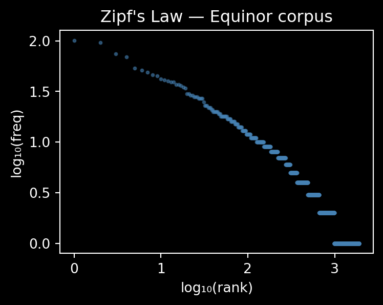

```python
cf = corpus_freq.copy().reset_index(drop=True)
cf["rank"] = range(1, len(cf) + 1)
fig, ax = plt.subplots(figsize=(4, 3.2))
ax.scatter(np.log10(cf["rank"]), np.log10(cf["n"]),
           s=4, alpha=0.5, color="steelblue")
ax.set(xlabel="log₁₀(rank)", ylabel="log₁₀(freq)",
       title="Zipf's Law — Equinor corpus")
plt.tight_layout(); plt.show()
```

## TF-IDF

- Adjusts raw frequency by rarity across the corpus
- **TF:** term frequency within one document
- **IDF:** log(N / df) — penalises common terms
- Up-weights distinctive, document-specific terms
- Standard baseline for retrieval and similarity

*Ch. 2, “TF-IDF”*

|  | carbon | emission | energy | policy | transition |
| --- | --- | --- | --- | --- | --- |
| d1 | 0.0 | 0.00 | 0.19 | 0.00 | 0.1 |
| d2 | 0.1 | 0.23 | 0.10 | 0.00 | 0.0 |
| d3 | 0.1 | 0.00 | 0.00 | 0.23 | 0.1 |

## Text Similarity & Visualization

- Cosine similarity: angle between TF-IDF vectors
- Jaccard similarity: token set overlap ratio
- Word clouds visualize corpus vocabulary at a glance
- Dependency parse trees show syntactic relations
- Visualization aids exploration, not statistical inference

*Ch. 2, “Feature Engineering” and “Word Clouds”*

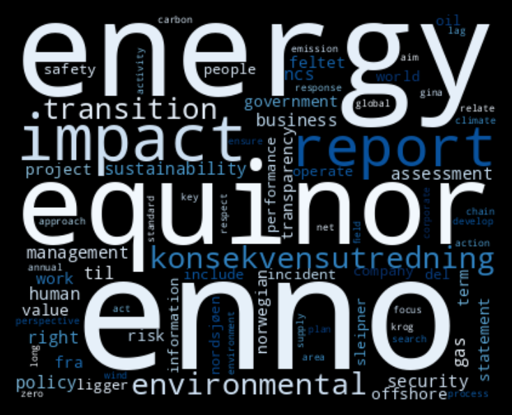

## Computer Lab Overview

- The lab uses Jupyter notebooks.
- Work proceeds step by step in cells.
- Students test code and inspect outputs.
- Markdown records decisions and interpretations.
- Notebooks support reproducible mini-projects.

## Choosing a Small Text Dataset

- Use a self-selected small dataset.
- Keep scope manageable for one session.
- Aim for a clear social question.
- Sources can be reviews, posts, or headlines.
- Save raw files before editing.

## Notebook Workflow for the Lab

- Create one notebook for loading data.
- Add cells for cleaning and inspection.
- Print intermediate outputs frequently.
- Document assumptions in markdown cells.
- Export final results for submission.

## Cleaning the Dataset

- Normalize casing and whitespace first.
- Remove URLs and stray punctuation.
- Handle emojis and hashtags deliberately.
- Drop empty or duplicate records.
- Keep a copy of original text.

## Tokenization in Practice

- Split cleaned text into tokens.
- Check whether punctuation should stay.
- Inspect sample token lists manually.
- Compare unigram and bigram choices.
- Match tokenizer to the dataset style.

## Deliverables from the Lab

- Show the chosen dataset and rationale.
- Demonstrate cleaning and tokenization steps.
- Report a few descriptive text statistics.
- Reflect on limits of the small sample.
- Prepare the notebook for discussion.

## Next steps

**Computer lab 1, apr 7**

- Link to lecture notes: https://cca-cce.github.io/osm-comm/web/edu/simp59-01tra.html

**References**

Ghosh, Sohom, and Dwight Gunning. 2019. *Natural Language Processing Fundamentals: Build Intelligent Applications That Can Interpret the Human Language to Deliver Impactful Results*. Packt Publishing Ltd.

Tight, Malcolm. 2019. *Documentary Research in the Social Sciences*.

Vasiliev, Yuli. 2020. *Natural Language Processing with Python and spaCy: A Practical Introduction*. No Starch Press.